# Visualization

## Facets

Faceting allows you to split a plot into multiple panels based on the values of one or more categorical variables. This is useful for comparing subgroups side-by-side.

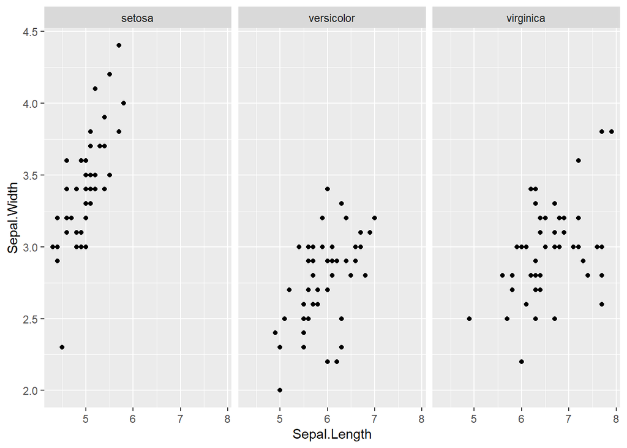

```r
# Scatter plot split by species
ggplot(iris, aes(x = Sepal.Length, y = Sepal.Width)) +
  geom_point() +
  facet_grid( ~ Species)
```

| Function | Description | Syntax Example |
| --- | --- | --- |
| `facet_wrap()` | Creates a series of plots wrapped into multiple rows or columns | `facet_wrap(~ variable)` |
| `facet_grid()` | Creates a grid of plots by combining one variable for rows and one for columns | `facet_grid(row_var ~ col_var)` |
| `facet_null()` | Default; no faceting applied | `facet_null()` |

### Additional Options

- `scales = "free"`: Allows each facet to have its own scale.
- `nrow`, `ncol`: Control layout in `facet_wrap()`.
- `labeller`: Customize facet labels.

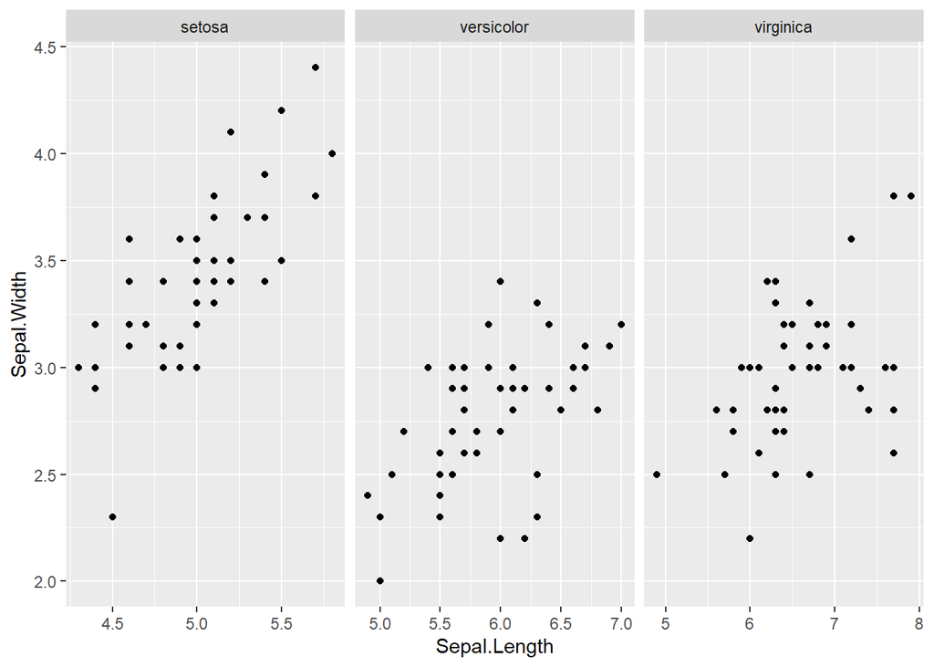

```r
ggplot(iris, aes(x = Sepal.Length, y = Sepal.Width)) +
  geom_point() +
  facet_grid(~ Species, scales = "free_x")
```

## Colors and fills in `ggplot2`

Controlling the **appearance** of plots is key to effective data visualization. In `ggplot2`, `color` and `fill` are used to modify how geometric objects look.

### `color` vs `fill`

| Aesthetic | Affects | Common in |
| --- | --- | --- |
| `color` | Outline or line color | `geom_point()`, `geom_line()` |
| `fill` | Inside (area) color | `geom_bar()`, `geom_boxplot()` |

#### Example: `color` and `fill` in a boxplot

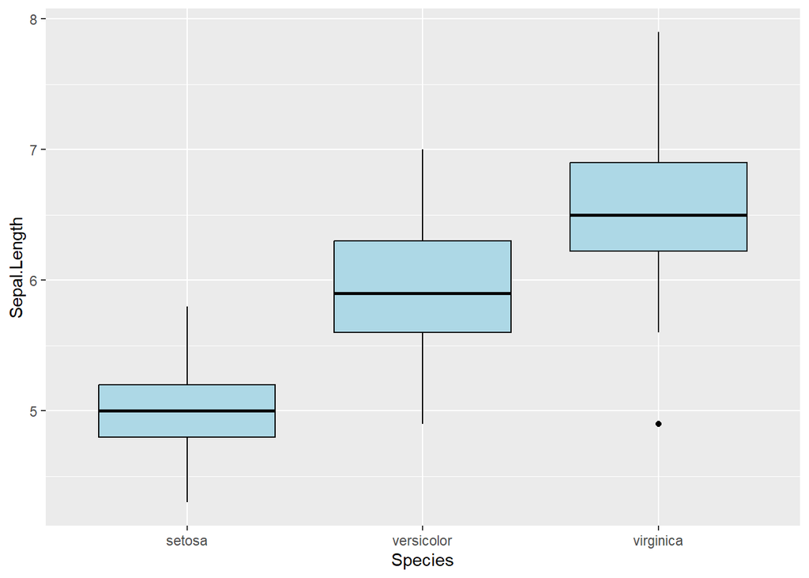

```r
ggplot(iris, aes(x = Species, y = Sepal.Length)) +
  geom_boxplot(color = "black", fill = "lightblue")
```

### Mapping vs Setting Colors

Mapped: Aesthetic is linked to a variable (aes(fill = Species))

Set manually: Aesthetic is fixed (fill = “skyblue”)

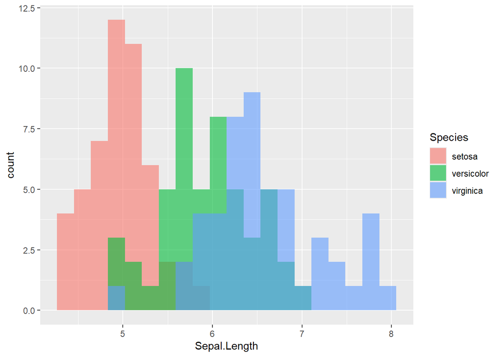

```r
# Mapping
ggplot(iris, aes(x = Sepal.Length, fill = Species)) +
  geom_histogram(bins = 20, position = "identity", alpha = 0.6)
```

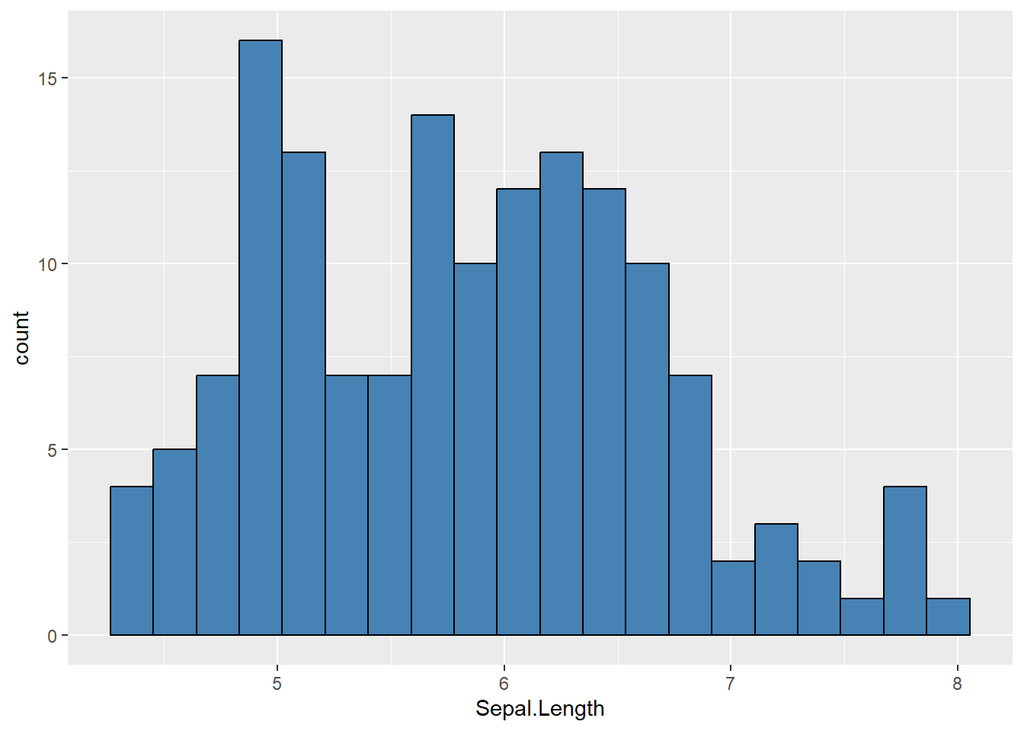

```r
# Setting
ggplot(iris, aes(x = Sepal.Length)) +
  geom_histogram(fill = "steelblue", color = "black", bins = 20)
```